# Laboratory exercise 1

##### By: Angela Madjar 181010

For this laboratory exercise I decided to work with the Game of Thrones (character-predictions.csv) dataset.

```python
import numpy as np
import pandas as pd
import seaborn as sns
import matplotlib.pyplot as plt

from sklearn.model_selection import cross_val_score, cross_val_predict, GridSearchCV, KFold, train_test_split
from sklearn.metrics import roc_auc_score, accuracy_score, roc_curve
from sklearn.metrics import confusion_matrix, classification_report
```

## 1. Preprocessing & EDA

```python
df = pd.read_csv("character-predictions.csv")
```

```python
df.head()
```

|  | S.No | actual | pred | alive | plod | name | title | male | culture | dateOfBirth | ... | isAliveHeir | isAliveSpouse | isMarried | isNoble | age | numDeadRelations | boolDeadRelations | isPopular | popularity | isAlive |
| --- | --- | --- | --- | --- | --- | --- | --- | --- | --- | --- | --- | --- | --- | --- | --- | --- | --- | --- | --- | --- | --- |
| 0 | 1 | 0 | 0 | 0.054 | 0.946 | Viserys II Targaryen | NaN | 1 | NaN | NaN | ... | 0.0 | NaN | 0 | 0 | NaN | 11 | 1 | 1 | 0.605351 | 0 |
| 1 | 2 | 1 | 0 | 0.387 | 0.613 | Walder Frey | Lord of the Crossing | 1 | Rivermen | 208.0 | ... | NaN | 1.0 | 1 | 1 | 97.0 | 1 | 1 | 1 | 0.896321 | 1 |
| 2 | 3 | 1 | 0 | 0.493 | 0.507 | Addison Hill | Ser | 1 | NaN | NaN | ... | NaN | NaN | 0 | 1 | NaN | 0 | 0 | 0 | 0.267559 | 1 |
| 3 | 4 | 0 | 0 | 0.076 | 0.924 | Aemma Arryn | Queen | 0 | NaN | 82.0 | ... | NaN | 0.0 | 1 | 1 | 23.0 | 0 | 0 | 0 | 0.183946 | 0 |
| 4 | 5 | 1 | 1 | 0.617 | 0.383 | Sylva Santagar | Greenstone | 0 | Dornish | 276.0 | ... | NaN | 1.0 | 1 | 1 | 29.0 | 0 | 0 | 0 | 0.043478 | 1 |

5 rows × 33 columns

```python
nRows, nCols = df.shape
print(f'This dataset has {nRows} rows and {nCols} columns.')
```

```
This dataset has 1946 rows and 33 columns.
```

```python
#I will drop the column S.No because it is just an index

df.drop('S.No', axis=1, inplace=True)
```

```python
#I will drop the columns actual, pred, alive and plod because of the suggested reasons

#The column isAlive indicates the current state of the character and will be dropped later only in the train set

df.drop(['actual', 'pred', 'alive', 'plod'], axis=1, inplace=True)
```

```python
nRows, nCols = df.shape
print(f'The dataset has {nRows} rows and {nCols} columns now.')
```

```
The dataset has 1946 rows and 28 columns now.
```

```python
df.head()
```

|  | name | title | male | culture | dateOfBirth | DateoFdeath | mother | father | heir | house | ... | isAliveHeir | isAliveSpouse | isMarried | isNoble | age | numDeadRelations | boolDeadRelations | isPopular | popularity | isAlive |
| --- | --- | --- | --- | --- | --- | --- | --- | --- | --- | --- | --- | --- | --- | --- | --- | --- | --- | --- | --- | --- | --- |
| 0 | Viserys II Targaryen | NaN | 1 | NaN | NaN | NaN | Rhaenyra Targaryen | Daemon Targaryen | Aegon IV Targaryen | NaN | ... | 0.0 | NaN | 0 | 0 | NaN | 11 | 1 | 1 | 0.605351 | 0 |
| 1 | Walder Frey | Lord of the Crossing | 1 | Rivermen | 208.0 | NaN | NaN | NaN | NaN | House Frey | ... | NaN | 1.0 | 1 | 1 | 97.0 | 1 | 1 | 1 | 0.896321 | 1 |
| 2 | Addison Hill | Ser | 1 | NaN | NaN | NaN | NaN | NaN | NaN | House Swyft | ... | NaN | NaN | 0 | 1 | NaN | 0 | 0 | 0 | 0.267559 | 1 |
| 3 | Aemma Arryn | Queen | 0 | NaN | 82.0 | 105.0 | NaN | NaN | NaN | House Arryn | ... | NaN | 0.0 | 1 | 1 | 23.0 | 0 | 0 | 0 | 0.183946 | 0 |
| 4 | Sylva Santagar | Greenstone | 0 | Dornish | 276.0 | NaN | NaN | NaN | NaN | House Santagar | ... | NaN | 1.0 | 1 | 1 | 29.0 | 0 | 0 | 0 | 0.043478 | 1 |

5 rows × 28 columns

```python
#Looking at the data types of the attributes (we will deal with the categorical attributes later)

df.info()
```

```
<class 'pandas.core.frame.DataFrame'>
RangeIndex: 1946 entries, 0 to 1945
Data columns (total 28 columns):
 #   Column             Non-Null Count  Dtype
---  ------             --------------  -----
 0   name               1946 non-null   object
 1   title              938 non-null    object
 2   male               1946 non-null   int64
 3   culture            677 non-null    object
 4   dateOfBirth        433 non-null    float64
 5   DateoFdeath        444 non-null    float64
 6   mother             21 non-null     object
 7   father             26 non-null     object
 8   heir               23 non-null     object
 9   house              1519 non-null   object
```

[output cut: 20 more lines]

```python
#Since there aren't any duplicates, we can conclude that the dataset contains information regarding 1946 different characters

print(df.duplicated().any())

print(df['name'].duplicated().any())
```

```
False
False
```

### 1.1. Handling missing values

```python
#Checking the number of null values for each attribute

df.isna().sum()
```

```
name                    0
title                1008
male                    0
culture              1269
dateOfBirth          1513
DateoFdeath          1502
mother               1925
father               1920
heir                 1923
house                 427
spouse               1670
book1                   0
book2                   0
book3                   0
book4                   0
book5                   0
isAliveMother        1925
isAliveFather        1920
isAliveHeir          1923
isAliveSpouse        1670
isMarried               0
isNoble                 0
age                  1513
numDeadRelations        0
boolDeadRelations       0
isPopular               0
popularity              0
isAlive                 0
dtype: int64
```

```python
#The percentage of missing values in the whole dataset

total_cells = np.product(df.shape)
missing_values_count = df.isnull().sum()
total_missing = missing_values_count.sum()
(total_missing/total_cells)*100
```

```
40.57407135516077
```

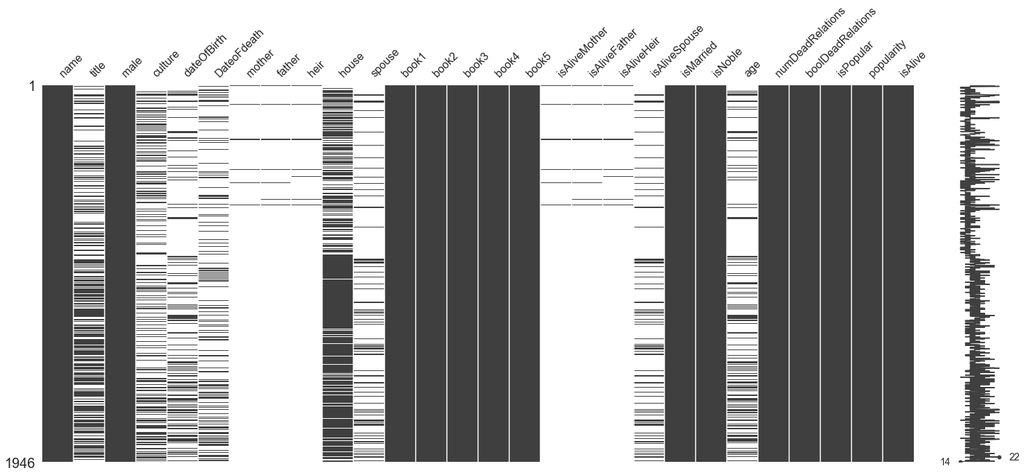

```python
#Visualizing the missing values

#Since there is a significant number of missing values, dropping rows isn't a good idea.
#Therefore, we'll try dealing with them

import missingno as msno

msno.matrix(df)
plt.show()
```

```python
#We can notice that the mean value of Age is a negative value and we have to figure out why this is happening

df.describe()
```

|  | male | dateOfBirth | DateoFdeath | book1 | book2 | book3 | book4 | book5 | isAliveMother | isAliveFather | isAliveHeir | isAliveSpouse | isMarried | isNoble | age | numDeadRelations | boolDeadRelations | isPopular | popularity | isAlive |
| --- | --- | --- | --- | --- | --- | --- | --- | --- | --- | --- | --- | --- | --- | --- | --- | --- | --- | --- | --- | --- |
| count | 1946.000000 | 433.000000 | 444.000000 | 1946.000000 | 1946.000000 | 1946.000000 | 1946.000000 | 1946.000000 | 21.000000 | 26.000000 | 23.000000 | 276.000000 | 1946.000000 | 1946.000000 | 433.000000 | 1946.000000 | 1946.000000 | 1946.000000 | 1946.000000 | 1946.000000 |
| mean | 0.619219 | 1577.364896 | 2950.193694 | 0.198356 | 0.374615 | 0.480473 | 0.591984 | 0.395170 | 0.714286 | 0.192308 | 0.652174 | 0.778986 | 0.141829 | 0.460946 | -1293.563510 | 0.305755 | 0.074512 | 0.059096 | 0.089584 | 0.745632 |
| std | 0.485704 | 19565.414460 | 28192.245529 | 0.398864 | 0.484148 | 0.499747 | 0.491593 | 0.489013 | 0.462910 | 0.401918 | 0.486985 | 0.415684 | 0.348965 | 0.498601 | 19564.340993 | 1.383910 | 0.262669 | 0.235864 | 0.160568 | 0.435617 |
| min | 0.000000 | -28.000000 | 0.000000 | 0.000000 | 0.000000 | 0.000000 | 0.000000 | 0.000000 | 0.000000 | 0.000000 | 0.000000 | 0.000000 | 0.000000 | 0.000000 | -298001.000000 | 0.000000 | 0.000000 | 0.000000 | 0.000000 | 0.000000 |
| 25% | 0.000000 | 240.000000 | 282.000000 | 0.000000 | 0.000000 | 0.000000 | 0.000000 | 0.000000 | 0.000000 | 0.000000 | 0.000000 | 1.000000 | 0.000000 | 0.000000 | 18.000000 | 0.000000 | 0.000000 | 0.000000 | 0.013378 | 0.000000 |
| 50% | 1.000000 | 268.000000 | 299.000000 | 0.000000 | 0.000000 | 0.000000 | 1.000000 | 0.000000 | 1.000000 | 0.000000 | 1.000000 | 1.000000 | 0.000000 | 0.000000 | 27.000000 | 0.000000 | 0.000000 | 0.000000 | 0.033445 | 1.000000 |
| 75% | 1.000000 | 285.000000 | 299.000000 | 0.000000 | 1.000000 | 1.000000 | 1.000000 | 1.000000 | 1.000000 | 0.000000 | 1.000000 | 1.000000 | 0.000000 | 1.000000 | 50.000000 | 0.000000 | 0.000000 | 0.000000 | 0.086957 | 1.000000 |
| max | 1.000000 | 298299.000000 | 298299.000000 | 1.000000 | 1.000000 | 1.000000 | 1.000000 | 1.000000 | 1.000000 | 1.000000 | 1.000000 | 1.000000 | 1.000000 | 1.000000 | 100.000000 | 15.000000 | 1.000000 | 1.000000 | 1.000000 | 1.000000 |

```python
#Detecting the rows in which the age is a negative value

print(df['age'][df['age'] < 0])
```

```
1684   -277980.0
1868   -298001.0
Name: age, dtype: float64
```

```python
#Creating a copy of the dataset and dropping the rows where the age is a negative value

df1 = df.drop([1684, 1868])
```

```python
#Calculating the mean without these two rows

average_age = round(df1["age"].mean(), 1)
average_age
```

```
36.8
```

```python
#Assigning the mean age to the attributes which had a negative value for the age

df.loc[1684, "age"] = average_age
df.loc[1868, "age"] = average_age
```

```python
#Doing the same for the missing values

print(df["age"].mean())

df['age'].fillna(round(df['age'].mean(), 1), inplace = True)
```

```
36.816628175519625
```

The remaining attributes are either binary or categorical (e.g. Title, Culture, mother etc.) such that, it would be pointless to substitute the nulls with the mode or by implementing KNN.

The only numerical attributes left unhandled are dateOfBirth and DateoFdeath.

Any kind of substitution of null values in the dateOfBirth attribute could result in inconsistency with the attribute age.

DateoFDeath signifies whether a character is still alive or not. We could be very wrong if we use, for example, KNN to substitute the null values.

Therefore, we will create a new category which will denote missing data - Unknown.

```python
df = df.fillna('Unknown')
```

```python
df.isna().sum()
```

```
name                 0
title                0
male                 0
culture              0
dateOfBirth          0
DateoFdeath          0
mother               0
father               0
heir                 0
house                0
spouse               0
book1                0
book2                0
book3                0
book4                0
book5                0
isAliveMother        0
isAliveFather        0
isAliveHeir          0
isAliveSpouse        0
isMarried            0
isNoble              0
age                  0
numDeadRelations     0
boolDeadRelations    0
isPopular            0
popularity           0
isAlive              0
dtype: int64
```